# Relatório de Análise Exploratória: Fatores de Satisfação do Cliente Olist

Pedro Coelho

10 de agosto de 2025

Introdução

Este relatório apresenta uma análise exploratória de dados sobre o dataset de e-commerce da Olist. O objetivo principal foi investigar os dados de vendas, entregas e avaliações para identificar os principais fatores que influenciam a satisfação do cliente. A análise foi conduzida em R, utilizando os pacotes dplyr para manipulação de dados e ggplot2 para visualização.

Preparação Inicial

Antes de iniciar a análise, carregamos as bibliotecas necessárias e o nosso conjunto de dados, que já foi previamente limpo e enriquecido em Python. Também garantimos que as colunas de regiao e mes fossem criadas para a análise.

```r
# 1. Carregar as bibliotecas essenciais
library(dplyr)
library(ggplot2)
library(lubridate)

# 2. Carregar o seu dataset (usando o caminho completo para garantir)
dados <- read.csv("C:/Users/Pedro Coelho/Downloads/OlistGeral/dataset_final_tratado.csv")

# 3. Recriar colunas que faltavam (apenas para garantir a execução no relatório)
dados <- dados %>%
  mutate(
    regiao_cliente = case_when(
      customer_state %in% c('SP', 'RJ', 'MG', 'ES') ~ 'Sudeste',
      customer_state %in% c('PR', 'SC', 'RS') ~ 'Sul',
      customer_state %in% c('DF', 'GO', 'MT', 'MS') ~ 'Centro-Oeste',
      customer_state %in% c('AL', 'BA', 'CE', 'MA', 'PB', 'PE', 'PI', 'RN', 'SE') ~ 'Nordeste',
      customer_state %in% c('AC', 'AP', 'AM', 'PA', 'RO', 'RR', 'TO') ~ 'Norte'
    ),
    order_purchase_timestamp = as_datetime(order_purchase_timestamp),
    mes_compra = floor_date(order_purchase_timestamp, "month")
  )
```

Análises e Visualizações

Gráfico 1: Faturamento por Estado

A primeira análise investiga a distribuição geográfica do faturamento. O gráfico de barras abaixo mostra o valor total de vendas para cada estado, ordenado do maior para o menor. Insight: Fica evidente a forte concentração de receita na região Sudeste. O estado de São Paulo (SP) se destaca como o principal mercado, responsável por uma porção significativamente maior do faturamento em comparação com os demais estados.

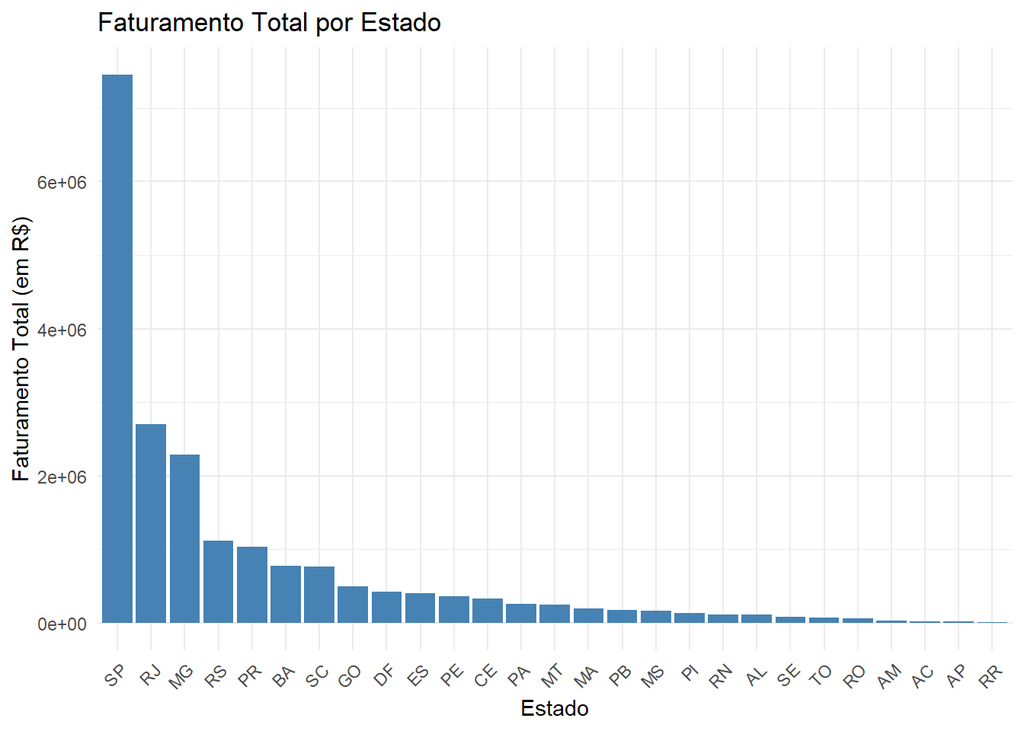

```r
faturamento_por_estado <- dados %>%
  group_by(customer_state) %>%
  summarise(faturamento_total = sum(payment_value, na.rm = TRUE)) %>%
  arrange(desc(faturamento_total))

ggplot(data = faturamento_por_estado, aes(x = reorder(customer_state, -faturamento_total), y = faturamento_total)) +
  geom_col(fill = "steelblue") +
  labs(title = "Faturamento Total por Estado", x = "Estado", y = "Faturamento Total (em R$)") +
  theme_minimal() +
  theme(axis.text.x = element_text(angle = 45, hjust = 1))
```

Gráfico 2: Comparação do Tempo de Entrega por Região

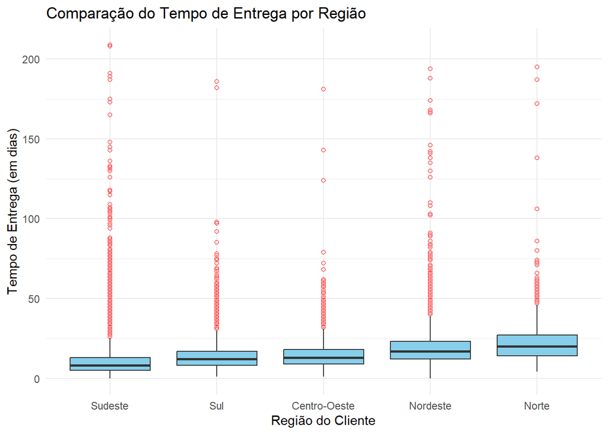

```r
ggplot(data = dados, aes(x = reorder(regiao_cliente, tempo_de_entrega, FUN = median), y = tempo_de_entrega)) +
  geom_boxplot(fill = "skyblue", outlier.colour = "red", outlier.shape = 1) +
  labs(title = "Comparação do Tempo de Entrega por Região", x = "Região do Cliente", y = "Tempo de Entrega (em dias)") +
  theme_minimal()
```

Gráfico 3: Evolução do Número de Pedidos ao Longo do Tempo

Analisar a quantidade de pedidos ao longo do tempo nos permite identificar tendências de crescimento e sazonalidade. O gráfico de linha abaixo mostra a evolução mensal do número de pedidos. Insight: O gráfico revela um crescimento expressivo e contínuo no volume de pedidos durante o ano de 2017, culminando em um pico acentuado em novembro de 2017, o que corresponde ao período da Black Friday. Após esse pico, o volume se estabiliza em um patamar mais elevado, indicando a maturação do negócio.

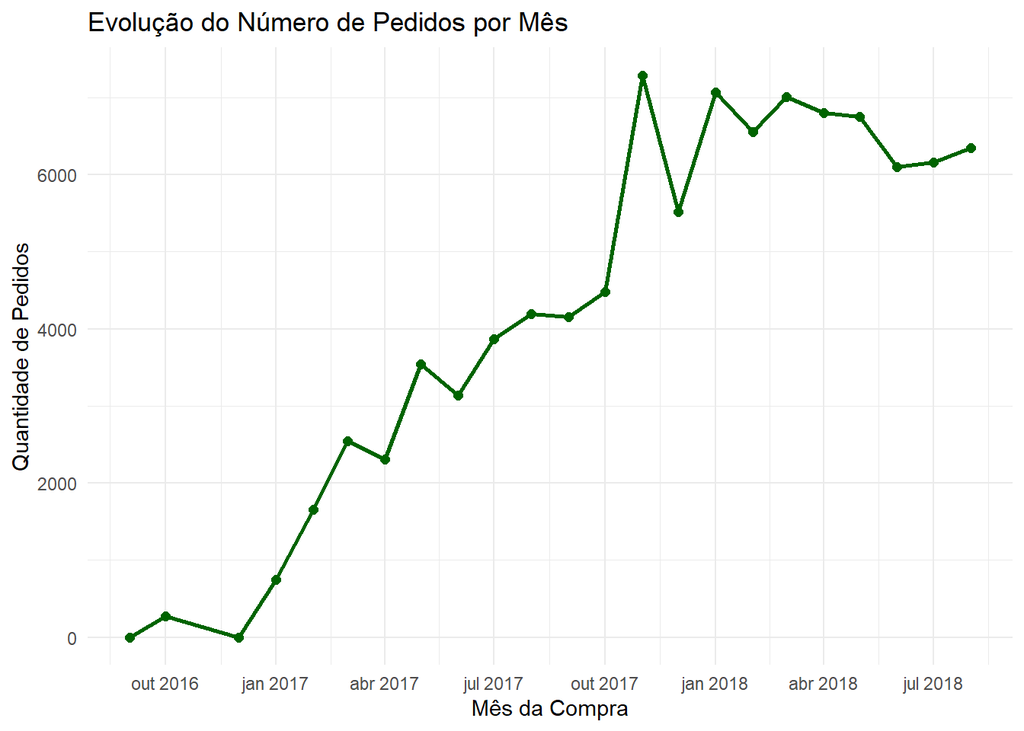

```r
pedidos_por_mes <- dados %>%
  group_by(mes_compra) %>%
  summarise(num_pedidos = n_distinct(order_id))

pedidos_por_mes$mes_compra <- as.Date(pedidos_por_mes$mes_compra)

ggplot(data = pedidos_por_mes, aes(x = mes_compra, y = num_pedidos)) +
  geom_line(color = "darkgreen", linewidth = 1) +
  geom_point(color = "darkgreen", size = 2) +
  labs(
    title = "Evolução do Número de Pedidos por Mês",
    x = "Mês da Compra",
    y = "Quantidade de Pedidos"
  ) +
  theme_minimal() +
  scale_x_date(date_labels = "%b %Y", date_breaks = "3 months")
```

Gráfico 4: Relação entre Atraso e Nota da Avaliação

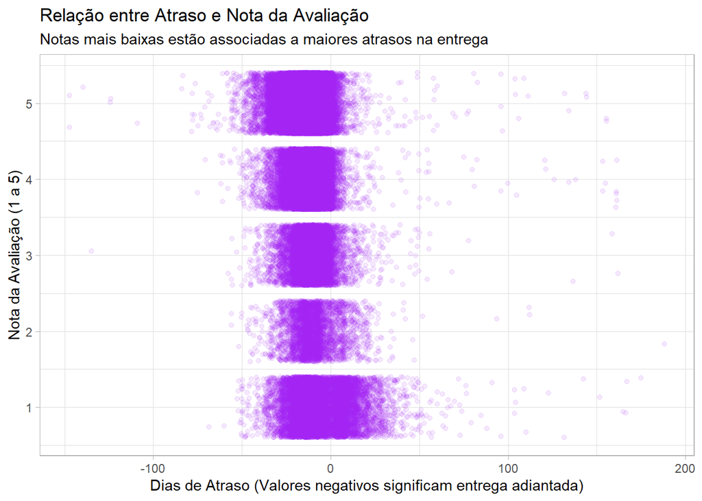

```r
ggplot(data = dados, aes(x = atraso_na_entrega, y = review_score)) +
  geom_jitter(alpha = 0.1, color = "purple") +
  labs(title = "Relação entre Atraso e Nota da Avaliação", subtitle = "Notas mais baixas estão associadas a maiores atrasos na entrega", x = "Dias de Atraso (Valores negativos significam entrega adiantada)", y = "Nota da Avaliação (1 a 5)") +
  theme_light()
```

Conclusão Final

A análise exploratória dos dados da Olist permitiu extrair insights valiosos sobre a operação da empresa. O principal fator que impacta negativamente a satisfação do cliente é o atraso na entrega. Enquanto o desempenho logístico é satisfatório nas regiões mais centrais do país, há uma clara oportunidade de melhoria nas regiões Norte e Nordeste, onde os tempos de entrega são mais longos e inconsistentes. Ações focadas em otimizar a logística e gerenciar as expectativas de prazo nessas áreas têm o maior potencial para elevar a satisfação geral dos clientes da plataforma.